# Single-cell Mapper

Gennaro Gambardella

TIGEM (Telethon Institute of Genetics and Medicine)

17 maggio 2023

#### Package

gficf 2.0.0

# Introduction

Single-cell Mapper (scMAP) is a transfer learning algorithm that combines text mining data transformation and a k-nearest neighbours’ (KNN) classifier to map a query set of single-cell transcriptional profiles on top of a reference atlas. scMAP consists of three main steps:

1. In the first step query cell profiles are normalized with the GF-ICF method but using the ICF weights learned by using the reference atlas;
2. In the second step, normalized cell profiles are first projected into the NMF (or PC) sub-space of the reference atlas and then mapped into its UMAP embedding space;
3. Finally, the KNN algorithm is used to contextualize mapped cells and annotate them.

Please read the manuscript for additional details and estimated performances of the method.

# 1 Building the reference atlas

For this tutorial, we will be using as a reference atlas the `small_BC_atlas dataset` included in the `gficf` package (Figure 1). This dataset is a small version (comprising only 4,760 cells) of the Breast cancer cell-line atlas we recently published ([Gambardella et al.](https://www.nature.com/articles/s41467-022-29358-6)).

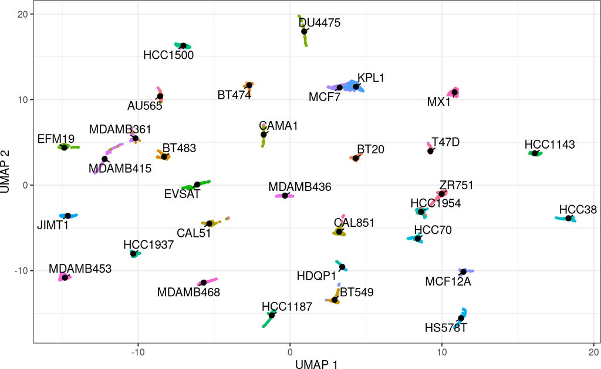

Figure 1: UMAP of referece BC Atlas  
UMAP plot of the small_BC_atlas dataset where cells are color-coded according to their cell-line of origin.

```r
require(gficf)
require(ggplot2)

# Step 1. Build the reference atlas
# Load the RAW UMI count matrix on which to build the reference atlas
data("small_BC_atlas")

# 1.1. Normalization and gene filtering
data <- gficf( M = small_BC_atlas,
               cell_count_cutoff = 15,
               nonz_mean_cutoff = 1.12,
               cell_percentage_cutoff2 = 0.05,
               normalize = T,
               verbose = T)

# 1.2 Create NMF (or PCA) subspace
# using all genes (usually improves performances)
data <- runNMF(data = data,dim = 50)

# 1.3 Create t-UMAP space
data <-runReduction(data = data,reduction = "umap",nt = 2,verbose = T)

# 1.4 Let's add info about the cell-line of origin
# Cell meta-data can stored in the data$embedded data.frame
# Let' add the info about the cell-line, stripping this information
# from the name of the cell and storing it into ccl column.
data$embedded$ccl = sapply(
                            strsplit(x = rownames(data$embedded),
                                     split = "_",fixed = T)
                            ,function(x) x[1]
                          )

# Plot cells by cell line of origin
p = plotCells(data = data,colorBy = "ccl",pointShape = 19) +
    xlab("UMAP 1") +
    ylab("UMAP 2")

plot(p)
```

# 2 How to map new cells into a reference atlas

After we have built our reference atlas (Figure 1), we use the 930 cells available into the `test_BC_atlas` dataset to test our mapping algorithm (Figure 2). Mapping of new cells into the embedded space of the reference atlas is performed by the `scMAP()` function. Metadata and coordinate of new mapped cells are stored into `data$embedded.predicted` data.frame.

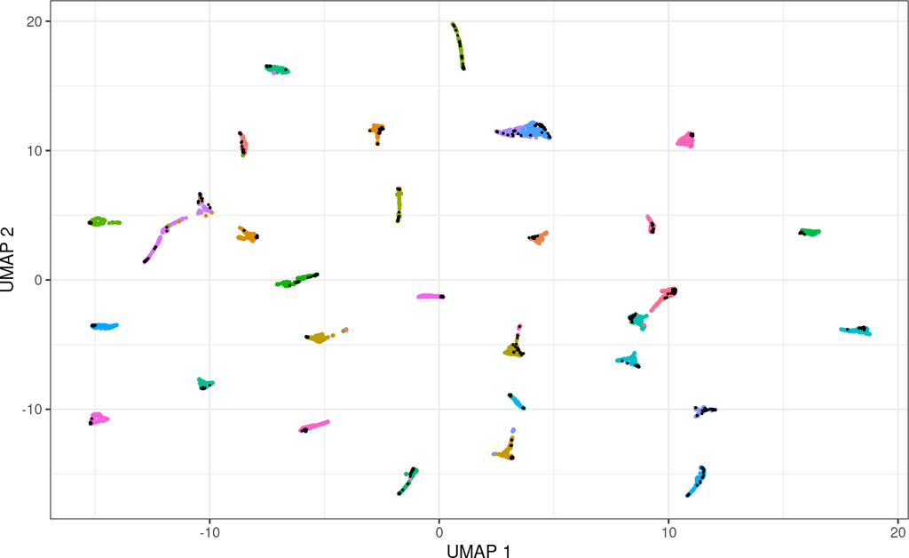

Figure 2: UMAP of referece BC Atlas and mapped cells  
UMAP plot of the small_BC_atlas dataset where cells are color-coded according to their cell-line of origin. Black points are the 930 mapped cells contained in the test_BC_atlas dataset

```r
# Step 2. Map new cells into reference atlas.
# 2.1 Load the new cells to map
data("test_BC_atlas")

# 2.2 Cell mapping
data = scMAP(data = data, x = test_BC_atlas,nt = 2,normalize = T,verbose = T)

# 2.3 Plot mapped cells
p = ggplot() +
    geom_point(data = data$embedded,aes(x=X,y=Y,color=ccl),
               shape=19,size=.5) +
    geom_point(data = data$embedded.predicted,aes(x=X,y=Y),
               color="black",shape=19,size=.2) +
    theme_bw() +
    xlab("UMAP 1") +
    ylab("UMAP 2") +
    theme(legend.position = "none")

plot(p)
```

# 3 How to contextualize mapped cells

The `classify.cells()` function is built on top of [`KernelKnn`](https://github.com/mlampros/KernelKnn) package and thus implement several measures to compute the distances among cells that can be specified trough the `knn_method` parameter. At the same time the parameter `knn_weights_fun` can be used to specify the kernel function to use for cell classification. Default is `knn_weights_fun = NULL` that correspond the to [unweighted KNN algorithm](https://en.wikipedia.org/wiki/K-nearest_neighbors_algorithm). For further details on possible kernel functions to use, plese see this [blog-post](http://mlampros.github.io/2016/07/10/KernelKnn/) of original `KernelKnn` package.

```r
# Step 3. Cell classification with KNN.
data = classify.cells(data = data,
                      classes = data$embedded$ccl,
                      k = 11,
                      knn_method = "manhattan",
                      knn_weights_fun = NULL)

# show top ten classified cells
head(data$embedded.predicted)
```

```
##                            X         Y predicted.class class.prob
## AU565_TCTTGACACAGT -8.603683 10.695223           AU565          1
## AU565_GTACTGTAATCC -8.509009  9.831717           AU565          1
## AU565_CCTGTGGCCTAT -8.550593  9.957725           AU565          1
## AU565_CATTGATAACAG -8.506574  9.853979           AU565          1
## AU565_TGTACAACCCTC -8.556398  9.874866           AU565          1
## AU565_GGAGTGACCAGC -8.519883  9.870450           AU565          1
```

```r
# Strip from cell name the cell-line
# of origin of each mapped cell
data$embedded.predicted$ccl = sapply(
                            strsplit(x = rownames(data$embedded.predicted),
                                     split = "_",fixed = T)
                            ,function(x) x[1]
                          )

# Now we can compute the classification accuracy
acc = sum(data$embedded.predicted$predicted.class==data$embedded.predicted$ccl)/nrow(data$embedded.predicted)*100
cat("Classification accuracy is",round(acc,2),"%")
```

```
## Classification accuracy is 93.33 %
```